# Cyclistic Bike-Share Analysis

Liu Hiu Lo (Ken)

2024-12-31

[figure not shown]

## Executive Summary

This analysis examines Cyclistic bike-share data from December 2023 to November 2024 to identify strategies for converting casual riders into annual members. The project revealed distinct usage patterns between casual riders and annual members, with key differences in ride timing, duration, and location preferences. Based on these insights, I developed targeted recommendations for converting casual riders to annual members.

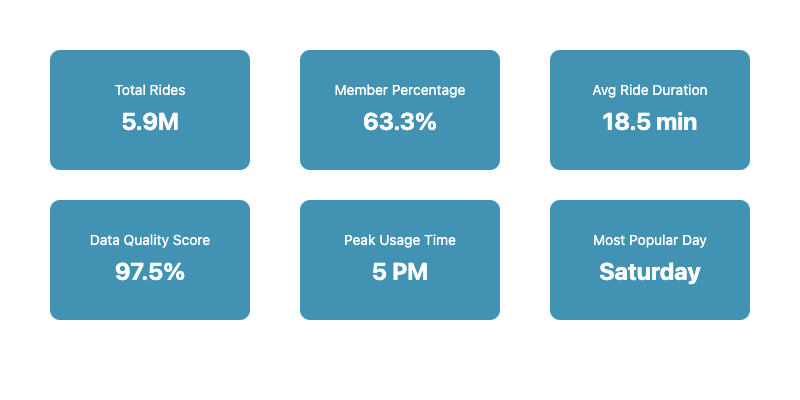

### Key Findings:

- Members primarily use bikes for commuting, with peak usage during rush hours
- Casual riders prefer weekend and leisure rides, with longer average trip durations
- Significant seasonal variation exists, particularly among casual riders
- Station usage patterns differ markedly between members and casual riders

| Metric | Value |
| --- | --- |
| Total Ride Records | 5,907,256 |
| Unique Ride Records | 5,906,058 |
| Member Percentage | 63.3% |

[figure not shown]

## 1. Introduction

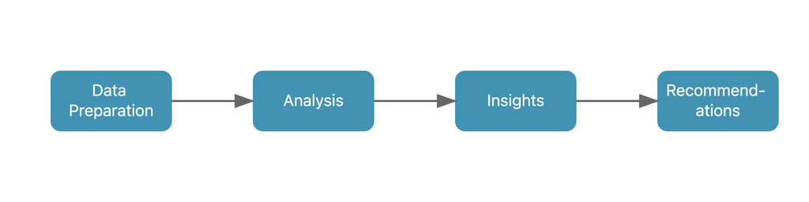

### 1.1 Project Overview

Cyclistic is a bike-share company operating in Chicago with a mission to maximize the number of annual memberships, which are more profitable than casual rides. This analysis aims to understand how annual members and casual riders use Cyclistic bikes differently to inform marketing strategies for converting casual riders into annual members.

### 1.2 Business Task

Primary objective: Develop data-driven recommendations for converting casual riders to annual members

#### Focus areas:

- Identify distinct usage patterns between member types
- Understand casual riders’ preferences and behaviors
- Discover opportunities for targeted conversion strategies

### 1.3 Stakeholders

- Lily Moreno: Director of Marketing
- Cyclistic Marketing Analytics Team
- Cyclistic Executive Team

## 2. Data Preparation

### 2.1 Data Overview

This analysis uses Cyclistic bike-share data from December 2023 to November 2024. The dataset contains over 5.9 million rides with detailed information about each trip.

```
## Rows: 5,907,256
## Columns: 14
## $ ride_id            <chr> "C9BD54F578F57246", "CDBD92F067FA620E", "ABC0858E52…
## $ rideable_type      <fct> electric_bike, electric_bike, electric_bike, electr…
## $ started_at         <dttm> 2023-12-02 18:44:01, 2023-12-02 18:48:19, 2023-12-…
## $ ended_at           <dttm> 2023-12-02 18:47:51, 2023-12-02 18:54:48, 2023-12-…
## $ start_station_name <chr> NA, NA, NA, NA, NA, NA, NA, NA, NA, NA, NA, NA, NA,…
## $ start_station_id   <chr> NA, NA, NA, NA, NA, NA, NA, NA, NA, NA, NA, NA, NA,…
## $ end_station_name   <chr> NA, NA, NA, NA, NA, NA, NA, NA, NA, NA, NA, NA, NA,…
## $ end_station_id     <chr> NA, NA, NA, NA, NA, NA, NA, NA, NA, NA, NA, NA, NA,…
## $ start_lat          <dbl> 41.92, 41.92, 41.89, 41.95, 41.92, 41.91, 41.99, 42…
## $ start_lng          <dbl> -87.66, -87.66, -87.62, -87.65, -87.64, -87.63, -87…
## $ end_lat            <dbl> 41.92, 41.89, 41.90, 41.94, 41.93, 41.88, 42.00, 41…
## $ end_lng            <dbl> -87.66, -87.64, -87.64, -87.65, -87.64, -87.65, -87…
## $ member_casual      <fct> member, member, member, member, member, member, mem…
## $ month_year         <dttm> NA, NA, NA, NA, NA, NA, NA, NA, NA, NA, NA, NA, NA…
```

Dataset Overview

| Total Rides | Unique Stations | Date Range | Member Rides | Casual Rides |
| --- | --- | --- | --- | --- |
| 5907256 | 1823 | December 01, 2023 to November 30, 2024 | 3741943 | 2165313 |

### 2.2 Data Quality Assessment

I conducted a comprehensive data quality assessment to ensure reliable analysis:

Data Quality Metrics

[output not shown]

### 2.3 Data Cleaning Process

The cleaning process included:

1. **Geographic Validation**
   - Defined Chicago boundaries (41.6°N to 42.1°N, 87.9°W to 87.5°W)
   - Removed rides outside service area
   - Calculated ride distances using Haversine formula
2. **Temporal Cleaning**
   - Removed rides with invalid durations
   - Filtered out rides >24 hours or <1 minute
   - Standardized timestamps
3. **Feature Engineering**
   - Created time-based features (day, month, season)
   - Added ride categories (commute, leisure, etc.)
   - Calculated derived metrics (speed, distance)

Impact of Data Cleaning

| Metric | Value |
| --- | --- |
| Initial Rows | 5907256.00 |
| Final Rows | 5758127.00 |
| Rows Removed | 149129.00 |
| % Data Retained | 97.48 |

## 3. Analysis and Insights

### 3.1 Temporal Patterns

#### Daily Usage Patterns

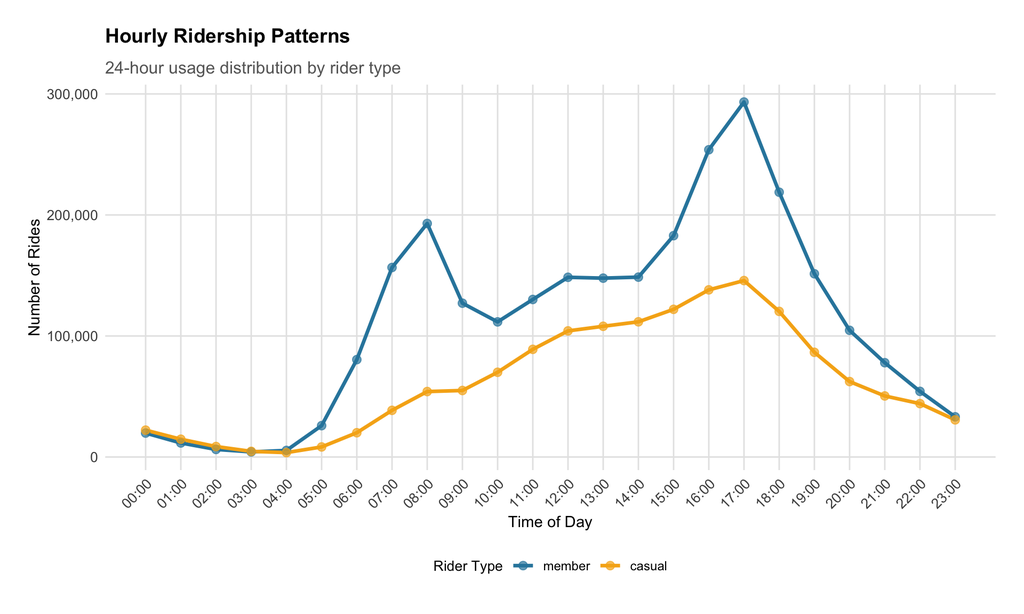

#### Weekly Patterns

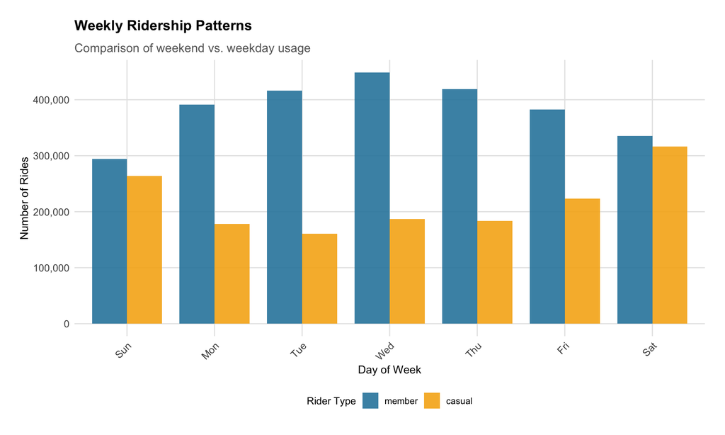

##### Insights:

- Weekend usage dominates casual riding patterns
- Members maintain consistent weekday usage
- Saturday shows highest overall system usage

#### Seasonal Variations

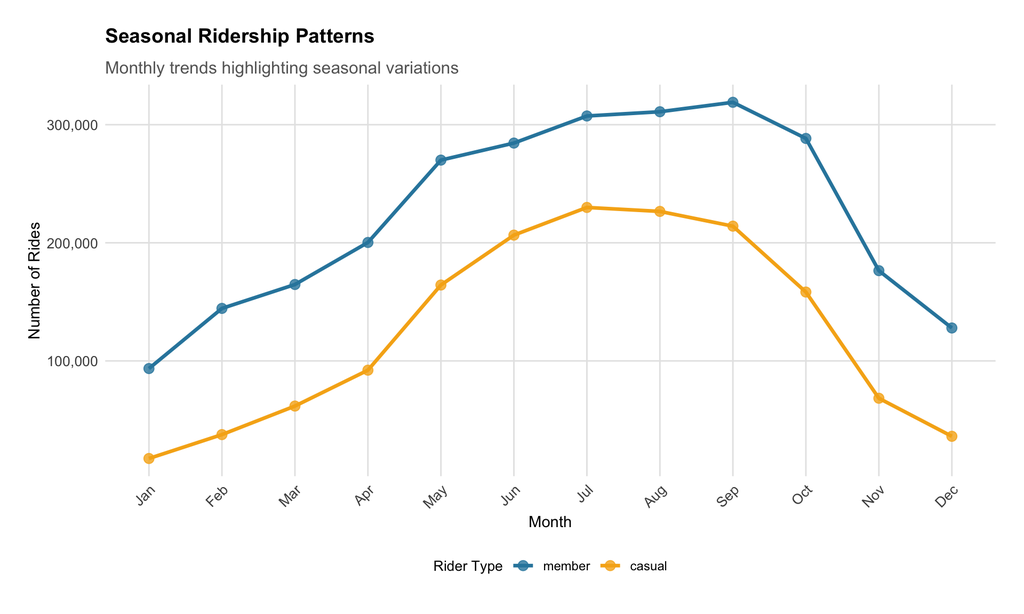

- **Seasonal Patterns:** Both member and casual riders show peak usage during summer months, but a substantial drop for casual riders in the fall

### 3.2 User Behavior Analysis

#### Usage Patterns by User Type

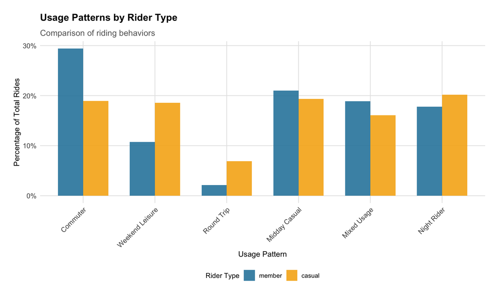

#### Trip Characteristics

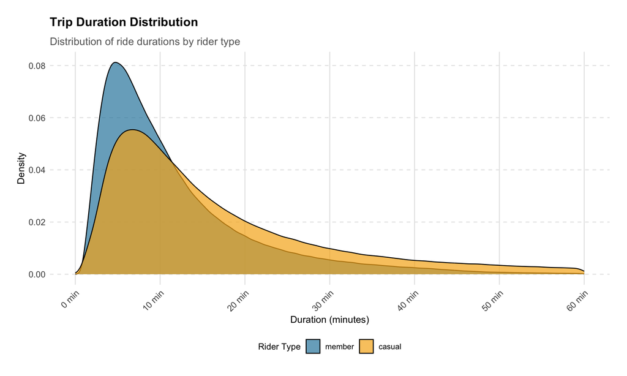

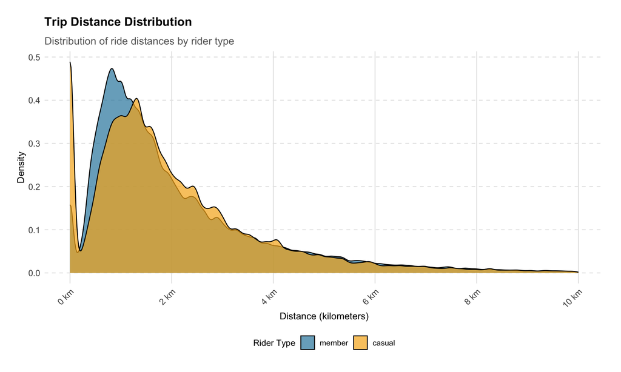

- **Trip Duration and Distance:** Members have a relatively shorter average ride duration and distance, while casual riders have a slightly wider distribution, which suggests casual riders explore a variety of routes and stations

### 3.3 Geographic Analysis

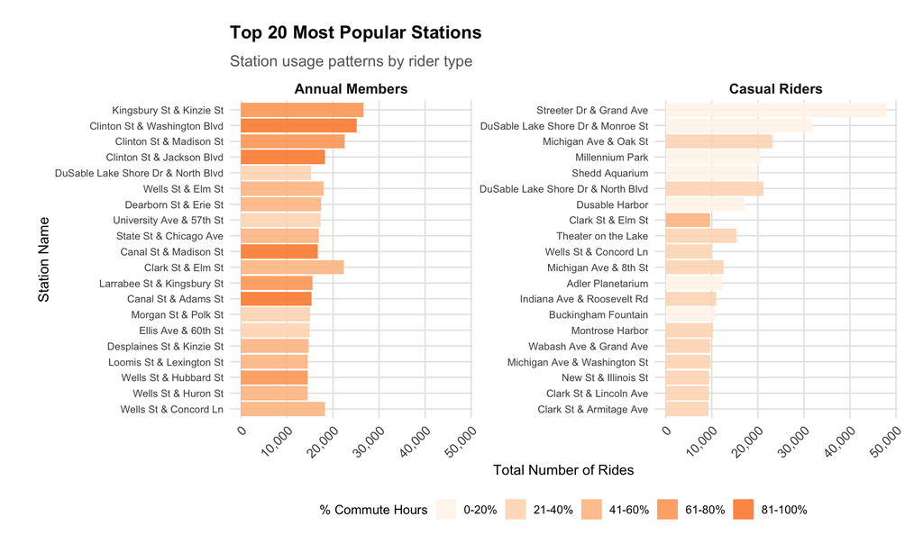

#### Station Usage Patterns:

- Popular member stations cluster near business districts
- Casual riders frequent tourist areas
- Station utilization varies significantly by time of day

## 4. Key Findings and Recommendations

### 4.2 Recommendations

1. **Targeted Commuter Conversion Program**
   - Identify casual riders who regularly ride during commute hours
   - Offer special “Commuter Trial” membership
   - Highlight cost savings for regular commuters
2. **Weekend-to-Weekday Extension Strategy**
   - Create “Weekend Plus” membership tier
   - Offer graduated discounts for weekday rides
   - Partner with local attractions

   Metrics for Success:
   - Weekend-to-weekday conversion rate
   - Membership upgrade rate
   - Partner location usage
3. **Seasonal Retention Program**
   - Implement early-bird winter discounts
   - Create seasonal challenges and rewards
   - Provide weather protection guarantees

## 5. Implementation and Next Steps

### 5.1 Action Plan

1. **Immediate Actions (Q1 2025)**
   - Launch Commuter Trial Program
   - Develop mobile app features for tracking rewards
   - Establish partnership agreements
2. **Medium-term Goals (Q2-Q3 2025)**
   - Roll out seasonal challenges
   - Implement technology improvements
   - Expand station coverage in key areas
3. **Long-term Objectives (Q4 2025+)**
   - Full loyalty program integration
   - Dynamic pricing system
   - Predictive maintenance implementation

### 5.2 Success Metrics

#### Track the following KPIs:

- Conversion rate from casual to annual members
- Retention rate of converted members
- Usage patterns of new members
- Revenue per user
- Customer satisfaction scores

### 5.3 Limitations and Future Research

#### **Current Limitations:**

- No individual user tracking across rides
- Weather data not integrated
- Limited demographic information
- No pricing sensitivity data

#### **Future Research Opportunities:**

- Impact of weather on ridership
- Price elasticity study
- Demographic analysis
- Multi-city comparison study